# Replication of Study: How Quick Decisions Illuminate Moral Character

Author

Luna Bellitto (lbellitto@ucsd.edu)

Published

December 11, 2024

## Introduction

This report presents our replication of the study “How Quick Decisions Illuminate Moral Character” conducted by Critcher, Inbar, and Pizarro (2013), which examined the effect of decision speed on judgments of moral character. The original study found that individuals who made quick moral decisions were evaluated more positively, whereas those who made quick immoral decisions were judged more harshly. In contrast, slower decisions, whether moral or immoral, led to more moderate evaluations of character. The authors proposed that quick decisions are seen as more certain and, therefore, more revealing of the decision maker’s underlying motives.

The original study employed two experiments. The first involved participants evaluating two individuals’ moral character, one who made a quick decision and another who took longer to decide, in both ethical and unethical contexts. The second experiment explored a similar structure but focused on more complex moral dilemmas. Both experiments consistently showed that quick decisions amplified moral evaluations, with quick moral decisions being judged more favorably and quick immoral decisions being judged more harshly.

Our replication aimed to reproduce the findings of the first experiment by closely following the original methodology. Specifically, we focused on testing whether decision speed continued to amplify moral character judgments, with quick decisions leading to more polarized evaluations compared to slower ones. This replication project is part of a broader effort to assess the robustness of psychological research through reproducibility studies.

## Methods

### Power Analysis

In the absence of prior data or specific effect size estimates from our study to conduct a traditional power analysis, we followed standard practice and increased our original sample size of 119 by a factor of 2.5, setting a target of 298 participants. This approach was intended to ensure adequate power to detect effects across conditions, compensating for the lack of data.

### Planned Sample

For our replication experiment, we would require a sample size of 298 participants. In the original study, the participants were students from the University of California, Berkeley or members from the nearby community who were randomly assigned to different conditions to assess the influence of decision speed on moral evaluations. However, participants for this replication study were recruited through Prolific and screened to ensure they reside in the US and are fluent in English.

### Materials

All the materials for this replication study come from the original study, *How Quick Decisions Illuminate Moral Character*, conducted by Critcher, Inbar, and Pizarro (2013). Our paradigm can be found [here](https://ucsd-psych201a.github.io/critcher2013_3/).

#### Scenario:

Participants were randomly assigned to one of two conditions: moral or immoral. Within each condition, two agents, Justin and Nate, were presented, differing in their decision-making speed.

- **Moral Condition**: In separate instances, Justin and Nate encounter a cash-filled wallet in a grocery store parking lot. Justin quickly decides to return the wallet to customer service rather than keeping the money. Nate ultimately makes the same decision, but only after a prolonged period of deliberation.
- **Immoral Condition**: In separate instances, Justin and Nate find a cash-filled wallet in a grocery store parking lot. Justin quickly decides to take the money and leave. Nate reaches the same conclusion but only after taking a long time to decide.

#### Questionnaire:

Participants were asked to answer the following questions based on their evaluation of each agent, Justin and Nate. Each question corresponds to one of the categories below, with its own specific scale.

##### Quickness:

1. Did [name] make his decision quickly or slowly?  
   **Scale:** 1 = particularly slowly, 7 = particularly quickly

##### Moral character evaluation:

2. Regardless of [name]’s decision, does it sound like [name] has underlying moral principles that are good, bad, or somewhere in between?  
   **Scale:** 1 = completely bad, 4 = mixed, 7 = completely good
3. Regardless of [name]’s decision, do you think [name] has moral standards that are good, bad, or somewhere in between?  
   **Scale:** 1 = completely bad, 4 = mixed, 7 = completely good
4. Regardless of [name]’s decision, do you think [name] possesses the moral knowledge and principles necessary to do ‘the right thing’?  
   **Scale:** 1 = not at all, 4 = somewhat, 7 = completely

##### Certainty:

5. Would you say [name] was quite certain in his decision, or did [name] have hesitations about his decision?  
   **Scale:** 1 = completely certain, 7 = considerable hesitations
6. How close do you think [name] was to choosing the alternate course of action?  
   **Scale:** 1 = very close to, 7 = not close at all
7. How conflicted do you think [name] felt in making the decision?  
   **Scale:** 1 = very conflicted, 7 = not at all conflicted
8. Based on the information provided, do you think [name] had many reservations about the decision?  
   **Scale:** 1 = none at all, 7 = a whole lot

##### Emotional impulsivity:

9. Do you think [name] was calm and emotionally contained while making the decision?  
   **Scale:** 1 = not at all, 7 = entirely so
10. To what extent do you think [name] became upset and acted without thinking?  
    **Scale:** 1 = not at all, 7 = entirely so

### Procedure

As in the original experiment (Critcher et al., 2013), our paradigm followed this procedure: “Participants read about Justin and Nate, two men who each independently came upon cash-filled wallets in the parking lot of a local grocery store”. Justin ‘was able to decide quickly’ what to do, while Nate ‘was only able to decide after long and careful deliberation.’ Participants assigned to the moral condition learned that both men ‘did not steal the money but instead left the wallet with customer service.’ Those in the immoral condition learned that both men ‘pocketed the money and drove off.’”

Adhering to the procedures outlined by Critcher et al. (2013), after reading the scenario of Justin and Nate’s actions, participants completed four Likert-scale assessments, each scaled from 1 to 7. The first assessment evaluated the quickness of the actors’ decisions (manipulation check). The second assessed Justin and Nate’s morality, with items such as: “has entirely good (vs. entirely bad) moral principles,” “has good (vs. bad) moral standards,” and “deep down has the moral principles and knowledge to do the right thing.” The third assessment included four items evaluating the certainty of the actors’ decisions, such as: “how conflicted [each] felt when making his decision,” “how many reservations [each] had,” “was quite certain in his decision,” and “how far [each] was from choosing the alternate course of action.” Finally, the fourth assessment evaluated perceived emotional impulsivity, asking whether the actors were “calm and emotionally contained” or “upset and acted without thinking.”

### Design Overview

#### Factors

In this replication study, two factors were manipulated: participants were randomly assigned to a condition (moral vs. immoral), and within each condition, they were exposed to both scenarios where one actor made the decision quickly (moral or immoral), and the other made the same decision slowly.

#### Primary Measures

Four primary measures were collected from participants:

1. **Quickness of Decision**: A manipulation check assessing participants’ perceptions of how quickly Justin and Nate made their decisions (e.g., “Did [name] make his decision quickly or slowly?”).
2. **Moral Character Evaluation**: Participants rated each agent’s moral principles and standards using items such as, “Does [name] have underlying moral principles that are good, bad, or somewhere in between?” and “Does [name] possess the moral knowledge and principles necessary to do the right thing?”
3. **Certainty**: Four items evaluated participants’ perceptions of each agent’s certainty in their decision, including “How conflicted [name] felt when making the decision” and “How close [name] was to choosing the alternate course of action.”
4. **Emotional Impulsivity**: Two items assessed perceptions of each agent’s emotional impulsivity, such as “Was [name] calm and emotionally contained?” and “Did [name] become upset and act without thinking?”

#### Mixed Design

The replication study reflects the original study’s mixed design:

- **Between-Subjects Factor**:
  - **Moral Condition (moral vs. immoral)**: Participants were randomly assigned to one of two conditions—moral (where both characters return the wallet) or immoral (where both characters keep the wallet). Each participant experienced only one of these conditions, making this factor between-subjects.
- **Within-Subjects Factor**:
  - **Decision Speed (quick vs. deliberative)**: Each participant evaluated both Justin (quick decision) and Nate (deliberative decision). Because every participant observed and evaluated both decision speeds within their assigned condition, this factor is within-subjects.

#### Impact of Switching Between- and Within-Subjects Designs

Although this replication followed the original study’s mixed design, switching both factors (decision and speed) to either a fully within-subjects or fully between-subjects design is a possible choice.

A fully within-subjects design could increase statistical power and require fewer participants, as each person would experience all combinations of conditions (quick/slow and moral/immoral). This design reduces variability due to individual differences, making it easier to detect effects. However, it could also risk carryover effects, where experiencing one condition might influence responses in the next, potentially producing biased results. Additionally, participants may guess the study’s purpose and alter their responses to appear consistent or meet the experiment’s expectations.

In contrast, in a fully between-subjects design, each participant would experience only one combination of decision speed and moral condition, requiring a larger sample size to achieve reliable effects. With only one condition per participant, variability due to individual differences is higher, which reduces statistical power and sensitivity to detect effects. However, this design minimizes potential biases, such as carryover effects and demand characteristics, as participants encounter only one scenario.

#### Potential Confounding Variables

Potential confounding variables in this study include but are not limited to participants’ own biases and preconceptions about the decision-making process, which can manifest as personal perceptions of quick versus slow decisions and overall moral judgments. Another important confound relates to preconceptions about men’s moral character, as both characters in the scenario are male, and participants may carry implicit gender biases that influence their evaluations. Additionally, cultural perspectives, participants’ emotional states and contexts, as well as the moral complexity of the scenarios, may further impact these judgments.

### Differences from Original Study

This replication differs from the original study primarily in the participant sample and mode of data collection. Participants for this replication were recruited through the online platform Prolific, rather than from a local population at a university. Consequently, this replication was conducted entirely online and targeted a sample size of 300 participants, larger than the original sample of 119. Additionally, this replication focused exclusively on Experiment 1 from the original study and did not include subsequent experiments.

### Methods Addendum (Post Data Collection)

#### Actual Sample

For our replication experiment, we would require at least a sample size of 298 participants. In the original study, the 119 participants were students from the University of California, Berkeley or members from the nearby community who were randomly assigned to different conditions to assess the influence of decision speed on moral evaluations. However, participants for this replication study will be recruited through the data collection platform, Prolific, and only screened for residing in the US and being fluent in English.

#### Differences from pre-data collection methods plan

Within the CSS 204 course, three independent teams worked on replicating Critcher, Inbar, and Pizarro’s study, each conducting separate data collection efforts. Combined, these efforts aligned with the target sample size of 300 specified in our planned power analysis (rounded from 298). To facilitate the analysis, our Teaching Assistant, Janna Wennberg, merged the cleaned datasets from all three teams. She carefully organized the data to ensure consistency and accuracy for our individual analyses. This combined dataset provided greater statistical power and a broader participant base, while still allowing for comparisons between the combined dataset and the individual datasets collected by our team.

For this analysis, we used both the merged dataset and the individual dataset specific to our group (group 3) to run our confirmatory analysis: 2x2 Anova. Additionally, we reverse-coded items related to decision certainty (from our combined dataset) to align with the original study’s methodology. These steps were implemented to ensure consistency across datasets and preserve the validity of our findings.

## Results

### Data preparation

Our replication of Experiment 1 will closely mirror the original study’s 2x2 factorial design, manipulating moral condition (stealing vs. not stealing) and decision speed (quick vs. slow). The dependent variable will be the moral character evaluation, assessed using a Likert scale. As in the original study, this replication will also examine perceived certainty of the actor in the scenario as covariates. The questionnaire items for the covariates will also be assessed using a Likert scale.

#### Raw Data Processing

```r
#### Load necessary libraries
library(tidyverse)
library(dplyr)
library(car)
library(emmeans)
library(effectsize)
library(lme4)
library(ggplot2)
library(lmerTest)

# Define the directory containing your CSV files
directory_path <- "../data/final-data"

# Initialize an empty tibble to store all cleaned data
cleaned_data <- tibble()

# Get a list of all CSV files in the directory
file_list <- list.files(path = directory_path, pattern = "\\.csv$", full.names = TRUE)

# Loop through each file in the directory
for (file in file_list) {
  # Read the CSV file
  data <- read_csv(file)

  # Flag to track if the attention check passes
  attention_check_passed <- FALSE

  # Check attention check questions
  attention_check_row <- data %>%
    filter(trial_type == "survey-html-form")

  # Validate attention check
  if (nrow(attention_check_row) > 0) {
    # Parse the JSON string in the response column
    attention_responses <- jsonlite::fromJSON(attention_check_row$response)

    # Define correct answers for attention check
    correct_answers <- list(
      "q1" = "Justin and Nate",
      "q2" = "A wallet"
    )

    # Check if all attention check answers are correct
    attention_check_passed <- all(
      attention_responses$q1 == correct_answers$q1 &&
        attention_responses$q2 == correct_answers$q2
    )
  }

  # Process data only if attention check passes
  if (attention_check_passed) {
    # Select relevant columns (do not drop NAs here)
    temp_cleaned <- data %>%
      select(condition, scenario, starts_with("response_Q"))

    # Determine who came first based on the first non-NA scenario entry
    temp_cleaned <- temp_cleaned %>%
      group_by(condition) %>%
      mutate(
        first_scenario = first(na.omit(scenario))  # Identify the first scenario for each participant
      ) %>%
      ungroup()

    # Convert condition to a factor for easier interpretation
    temp_cleaned <- temp_cleaned %>%
      mutate(
        condition = factor(condition, levels = c(0, 1), labels = c("immoral", "moral")),
        scenario = factor(scenario)
      ) %>%
      # Rearrange columns to place first_scenario after condition
      select(condition, first_scenario, scenario, starts_with("response_Q"))

    # Rename response columns to include scenario information
    temp_cleaned <- temp_cleaned %>%
      # Ensure no NA in 'scenario' or 'question' before combining
      filter(!is.na(scenario)) %>%
      pivot_longer(cols = starts_with("response_Q"),
                   names_to = "question",
                   values_to = "response") %>%
      # Remove rows where both 'question' and 'response' are NA
      filter(!is.na(question) & !is.na(response)) %>%
      unite("question_scenario", scenario, question, sep = "_") %>%
      pivot_wider(names_from = question_scenario, values_from = response)

    # Append the cleaned data from this file to the main cleaned_data tibble
    # Ensure rows with NAs are retained by not filtering them out
    cleaned_data <- bind_rows(cleaned_data, temp_cleaned)
  } else {
    # If attention check fails, log the file name (optional)
    message(paste("Attention check failed for file:", file))
  }
}

# View the final combined cleaned_data tibble
print(cleaned_data)
```

```
# A tibble: 95 × 22
   condition first_scenario Justin_response_Q1 Justin_response_Q2
   <fct>     <chr>                       <dbl>              <dbl>
 1 immoral   Justin                          7                  2
 2 moral     Justin                          7                  7
 3 immoral   Justin                          7                  3
 4 moral     Nate                            7                  7
 5 moral     Justin                          7                  6
 6 immoral   Nate                            7                  3
 7 immoral   Justin                          6                  3
 8 moral     Justin                          7                  7
 9 moral     Justin                          7                  6
10 moral     Justin                          7                  7
# ℹ 85 more rows
# ℹ 18 more variables: Justin_response_Q3 <dbl>, Justin_response_Q4 <dbl>,
#   Justin_response_Q5 <dbl>, Justin_response_Q6 <dbl>,
#   Justin_response_Q7 <dbl>, Justin_response_Q8 <dbl>,
#   Justin_response_Q9 <dbl>, Justin_response_Q10 <dbl>,
#   Nate_response_Q1 <dbl>, Nate_response_Q2 <dbl>, Nate_response_Q3 <dbl>,
#   Nate_response_Q4 <dbl>, Nate_response_Q5 <dbl>, Nate_response_Q6 <dbl>, …
```

```r
# Define the output path for the final cleaned CSV file
output_path <- "../data/cleaned_data_final.csv"

# Save the final combined cleaned_data tibble as a CSV file
write_csv(cleaned_data, output_path)
```

#### Combined Data Processing

```r
# Load the combined dataset
dat <- read.csv("../data/quick_decisions_combined.csv")  # Read the dataset into a data frame

### Implement Exclusion Criteria: For participant with incomplete answers and lack of variance

# Process the dataset
cleaned_data <- dat %>%
  # Step 1: Filter out missing values
  mutate(is_complete = complete.cases(.)) %>%
  filter(complete.cases(.)) %>%

  # Step 2: Calculate variance for Justin and Nate
  rowwise() %>%
  mutate(
    justin_variance = var(c(2:11), na.rm = TRUE), # Variance for Justin
    nate_variance = var(c(12:22), na.rm = TRUE)          # Variance for Nate
  ) %>%
  ungroup() %>%

  # Step 3: Filter out participants based on variance criteria
  filter(!(justin_variance == 0 | nate_variance == 0)) %>%

  # Step 4: Drop intermediate columns used for exclusion
  select(-is_complete, -justin_variance, -nate_variance)

# Step 5: Calculate exclusion counts
  na_exclusions_count <- nrow(dat) - nrow(dat %>% filter(complete.cases(.))) # Count rows with missing values
  variance_exclusions_count <- nrow(dat %>% filter(complete.cases(.))) - nrow(cleaned_data) # Count participants excluded for lack of variance
  total_exclusions <- na_exclusions_count + variance_exclusions_count  # Calculate total exclusions

# Step 6: Create a summary table of exclusions
exclusions_summary <- tibble(
  Exclusion_Criteria = c(
    "Missing values (NA)",
    "Lack of variance",
    "Total exclusions"
  ),
  Count = c(
    na_exclusions_count,
    variance_exclusions_count,
    total_exclusions
  )
)

# Display the table
print(exclusions_summary)
```

```
# A tibble: 3 × 2
  Exclusion_Criteria  Count
  <chr>               <int>
1 Missing values (NA)    84
2 Lack of variance        0
3 Total exclusions       84
```

#### Manipulation Check for Combined Dataset

Then we will determine whether there is a statistically significant difference in the mean scores of Justin’s speed and Nate’s speed.

```r
# Add Participant_ID column and make it the first column
cleaned_data <- cleaned_data %>%
  mutate(Participant_ID = row_number()) %>%
  select(Participant_ID, everything())

manipulation_stats <- cleaned_data %>%
  group_by(condition) %>%  # Group data by the 'condition' column
  summarize(
    mean_speed_justin = mean(Justin_Q1),  # Mean of Justin's speed
    mean_speed_nate = mean(Nate_Q1)     # Mean of Nate's speed
  )

# Paired t-test for Justin's and Nate's speeds for checking whether the manipulation was successful or not
manipulation_combined_t_test <- t.test(
  cleaned_data$Justin_Q1,
  cleaned_data$Nate_Q1,
  paired = TRUE
)


print(manipulation_combined_t_test)
```

```
    Paired t-test

data:  cleaned_data$Justin_Q1 and cleaned_data$Nate_Q1
t = 15.915, df = 206, p-value < 2.2e-16
alternative hypothesis: true mean difference is not equal to 0
95 percent confidence interval:
 2.116230 2.714688
sample estimates:
mean difference
       2.415459
```

### Confirmatory analysis

Since the objective of this replication study was to closely mirror the original methodology, the statistical analysis replicated the 2x2 ANOVA test used in the original study. This statistical approach allowed for a direct assessment of the main effects of decision speed and moral condition on moral character evaluations, as well as their interaction, within a consistent analytical framework.

The 2x2 ANOVA was particularly appropriate here because it provides a straightforward method for comparing group means across these two factors, making it ideal for testing the original hypotheses about how decision speed and moral outcome influence moral judgments. By using the same statistical test as the original study, we ensured that any differences in results could be attributed to sample or context rather than methodological inconsistencies.

To enhance the robustness of our findings, we performed the analysis on both the combined dataset (aggregated across all three teams) and our team-specific dataset. The combined dataset allowed us to evaluate the generalizability of the findings across a more diverse sample while maintaining alignment with the target sample size of 300. The team-specific dataset, on the other hand, allowed us to ensure that any patterns observed in the combined analysis were consistent with those from our independently collected data.

While other methods, such as a linear mixed-effects model, could offer flexibility, the 2x2 ANOVA preserves the simplicity and interpretability central to the original study’s analysis. By using this approach, we stay true to the original design and ensure consistency in our replication study.

#### Confirmatory Analysis for Combined Dataset

```r
### Step 1: Calculate Average Scores for Justin and Nate

character_eval_combined <- cleaned_data %>%
  mutate(
    # Calculate the average score for Justin across selected questions
    quick_justin_score = rowMeans(select(., Justin_Q2, Justin_Q3, Justin_Q4)),
    # Calculate the average score for Nate across selected questions
    slow_nate_score = rowMeans(select(., Nate_Q2, Nate_Q3, Nate_Q4))
  )

### Step 2: Summarize Average Scores by Condition

# Group data by condition for comparison of Justin's moral character evaluation and Nate's character evaluation across condition.

 character_eval_combined_stats <- character_eval_combined %>%
  group_by(condition) %>%  # Group data by the 'condition' column
  summarize(
    mean_justin = mean(quick_justin_score), # Mean of Justin's character evaluation
    mean_nate = mean(slow_nate_score)     # Mean of Nate's character evaluation
  )


### Step 3: Reshape Data for ANOVA
character_eval_combined_long <- character_eval_combined %>%
  pivot_longer(
    cols = c(quick_justin_score, slow_nate_score), # Select the new columns
    names_to = "speed",                           # Create a column for speed
    values_to = "score"                            # Create a column for scores
  ) %>%
  mutate(
    speed = ifelse(speed == "quick_justin_score", "Justin", "Nate") # Relabel speed column
  )  %>%
  select(Participant_ID, condition, speed, score) # Keep only essential columns



### Step 4: Run Repeated-Measures ANOVA
anova_combined <- aov(score ~ condition * speed + Error(Participant_ID/speed), data = character_eval_combined_long)
summary(anova_combined)
```

```
Error: Participant_ID
          Df Sum Sq Mean Sq
condition  1  2.109   2.109

Error: Participant_ID:speed
      Df  Sum Sq Mean Sq
speed  1 0.01332 0.01332

Error: Within
                 Df Sum Sq Mean Sq F value Pr(>F)
condition         1  324.1   324.1 312.655 <2e-16 ***
speed             1    0.1     0.1   0.053  0.819
condition:speed   1  198.2   198.2 191.208 <2e-16 ***
Residuals       408  422.9     1.0
---
Signif. codes:  0 '***' 0.001 '**' 0.01 '*' 0.05 '.' 0.1 ' ' 1
```

#### Confirmatory Analysis of Group 3’s data

This analysis focuses on a subset of the data, specifically Group 3. We will perform the same 2 (moral condition: moral vs. immoral) x 2 (decision speed: quick vs. slow) ANOVA as in the full dataset but restricted to Group 3. This allows us to assess whether the observed effects are consistent within this specific subset.

```r
### Sub setting the data
g3_cleaned_data <- cleaned_data %>%
  filter(group == 3)


### Step 1: Calculate Average Scores for Justin and Nate
character_eval_group3 <- g3_cleaned_data %>%
  mutate(
    # Calculate the average score for Justin across selected questions
    quick_justin_score = rowMeans(select(., Justin_Q2, Justin_Q3, Justin_Q4)),
    # Calculate the average score for Nate across selected questions
    slow_nate_score = rowMeans(select(., Nate_Q2, Nate_Q3, Nate_Q4))
  )

### Step 2: Summarize Average Scores by Condition

# Group data by condition for comparison of Justin's moral character evaluation and Nate's character evaluation across condition

 character_eval_group3_stats <- character_eval_group3 %>%
  group_by(condition) %>%  # Group data by the 'condition' column
  summarize(
    mean_justin = mean(quick_justin_score), # Mean of Justin's character evaluation
    mean_nate = mean(slow_nate_score)     # Mean of Nate's character evaluation
  )

### Step 3: Reshape Data for ANOVA
character_eval_group3_long <- character_eval_group3 %>%
  pivot_longer(
    cols = c(quick_justin_score, slow_nate_score), # Select the new columns
    names_to = "speed",                           # Create a column for speed
    values_to = "score"                            # Create a column for scores
  ) %>%
  mutate(
    speed = ifelse(speed == "quick_justin_score", "Justin", "Nate") # Relabel speed column
  )  %>%
  select(Participant_ID, condition, speed, score) # Keep only essential columns


### Step 4: Run Repeated-Measures ANOVA

anova_group3 <- aov(score ~ condition * speed + Error(Participant_ID/speed), data = character_eval_group3_long)
summary(anova_group3)
```

```
Error: Participant_ID
          Df Sum Sq Mean Sq
condition  1  4.634   4.634

Error: Participant_ID:speed
      Df  Sum Sq Mean Sq
speed  1 0.09317 0.09317

Error: Within
                 Df Sum Sq Mean Sq F value Pr(>F)
condition         1 112.75  112.75 113.878 <2e-16 ***
speed             1   4.96    4.96   5.011 0.0264 *
condition:speed   1  91.71   91.71  92.628 <2e-16 ***
Residuals       184 182.18    0.99
---
Signif. codes:  0 '***' 0.001 '**' 0.01 '*' 0.05 '.' 0.1 ' ' 1
```

#### Visualization

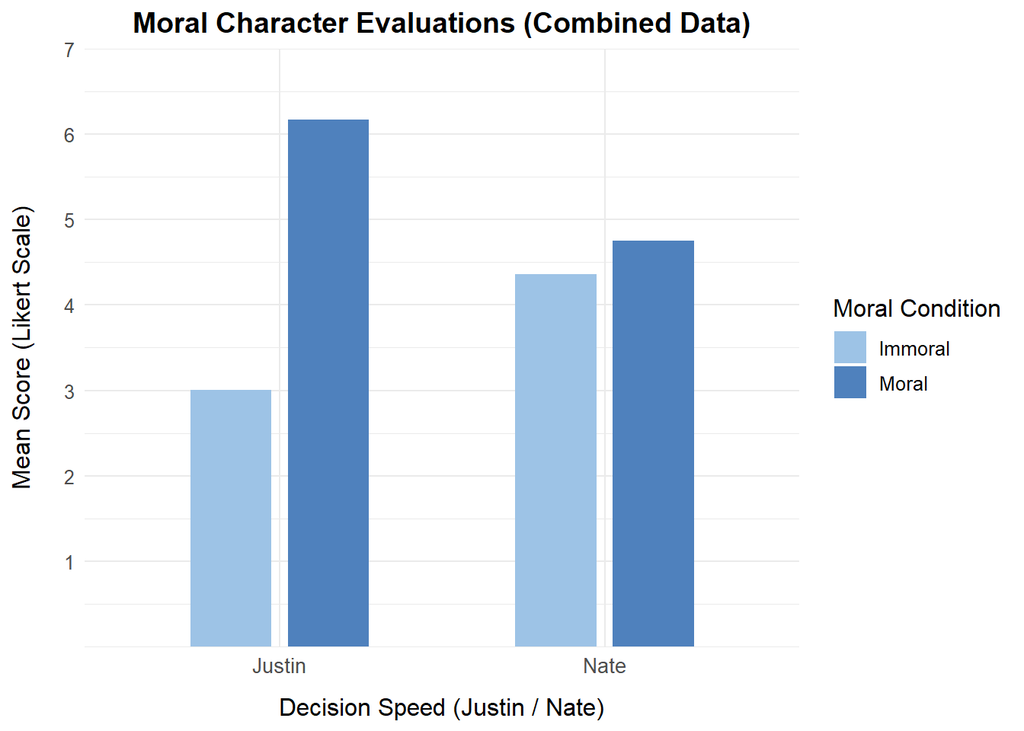

```r
ggplot(character_eval_combined_long, aes(x = speed, y = score, fill = condition)) +
  geom_bar(
    stat = "summary",
    fun = "mean",
    position = position_dodge(width = 0.6),  # Columns closer together
    width = 0.5                             # Narrower columns
  ) +
  labs(
    title = "Moral Character Evaluations (Combined Data)",
    x = "Decision Speed (Justin / Nate)",
    y = "Mean Score (Likert Scale)",  # Updated y-axis label
    fill = "Moral Condition"          # Legend title for conditions
  ) +
  theme_minimal() +
  theme(
    text = element_text(size = 12),
    plot.title = element_text(hjust = 0.5, face = "bold", size = 14),  # Centered title
    axis.text.x = element_text(size = 10),   # Adjust x-axis labels
    axis.title.y = element_text(size = 12, margin = margin(r = 15)),  # Add spacing to y-axis title
    axis.title.x = element_text(size = 12, margin = margin(t = 10))   # Add spacing to x-axis title
  ) +
  scale_fill_manual(
    values = c("moral" = "#4F81BD", "immoral" = "#9DC3E6"),  # Two shades for moral/immoral
    labels = c("moral" = "Moral", "immoral" = "Immoral")     # Custom legend labels
  ) +
  scale_y_continuous(
    limits = c(0, 7),  # Y-axis limits for Likert scale
    breaks = 1:7,      # Label y-axis by 1's
    expand = c(0, 0)   # No extra space above/below
  )
```

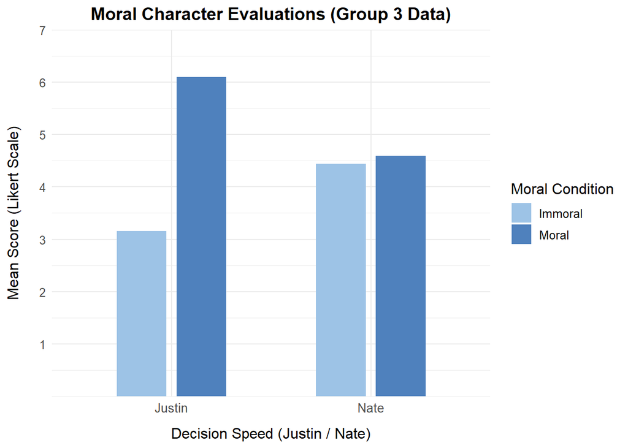

```r
ggplot(character_eval_group3_long, aes(x = speed, y = score, fill = condition)) +
  geom_bar(
    stat = "summary",
    fun = "mean",
    position = position_dodge(width = 0.6),  # Columns closer together
    width = 0.5                             # Narrower columns
  ) +
  labs(
    title = "Moral Character Evaluations (Group 3 Data)",
    x = "Decision Speed (Justin / Nate)",    # Updated x-axis label
    y = "Mean Score (Likert Scale)",         # Updated y-axis label
    fill = "Moral Condition"                # Legend title for conditions
  ) +
  theme_minimal() +
  theme(
    text = element_text(size = 12),
    plot.title = element_text(hjust = 0.5, face = "bold", size = 14),  # Centered title
    axis.text.x = element_text(size = 10),   # Adjust x-axis labels
    axis.title.y = element_text(size = 12, margin = margin(r = 15)),  # Add spacing to y-axis title
    axis.title.x = element_text(size = 12, margin = margin(t = 10))   # Add spacing to x-axis title
  ) +
  scale_fill_manual(
    values = c("moral" = "#4F81BD", "immoral" = "#9DC3E6"),  # Two shades for moral/immoral
    labels = c("moral" = "Moral", "immoral" = "Immoral")     # Custom legend labels
  ) +
  scale_y_continuous(
    limits = c(0, 7),  # Y-axis limits for Likert scale
    breaks = 1:7,      # Label y-axis by 1's
    expand = c(0, 0)   # No extra space above/below
  )
```